# final-project

## ITCS 3162 Final Project Code

By: [Philip Vishnevsky](https://github.com/zenatron), Nikole Sazoncika, Santhosh Balla, Pranav Rao, and Dylan Laborante

## 1. Introduction

```python
import pandas as pd
# Load the wine dataset
url = "https://archive.ics.uci.edu/ml/machine-learning-databases/wine/wine.data"  # UCI Machine Learning Repository link
columns = [
	"Alcohol", "Malic acid", "Ash", "Alcalinity of ash", "Magnesium",
	"Total phenols", "Flavanoids", "Nonflavanoid phenols", "Proanthocyanins",
	"Color intensity", "Hue", "OD280/OD315 of diluted wines", "Proline"
]
wine_df = pd.read_csv(url, header=None, names=columns)

# Display the first few rows
wine_df.head()
```

|  | Alcohol | Malic acid | Ash | Alcalinity of ash | Magnesium | Total phenols | Flavanoids | Nonflavanoid phenols | Proanthocyanins | Color intensity | Hue | OD280/OD315 of diluted wines | Proline |
| --- | --- | --- | --- | --- | --- | --- | --- | --- | --- | --- | --- | --- | --- |
| 1 | 14.23 | 1.71 | 2.43 | 15.6 | 127 | 2.80 | 3.06 | 0.28 | 2.29 | 5.64 | 1.04 | 3.92 | 1065 |
| 1 | 13.20 | 1.78 | 2.14 | 11.2 | 100 | 2.65 | 2.76 | 0.26 | 1.28 | 4.38 | 1.05 | 3.40 | 1050 |
| 1 | 13.16 | 2.36 | 2.67 | 18.6 | 101 | 2.80 | 3.24 | 0.30 | 2.81 | 5.68 | 1.03 | 3.17 | 1185 |
| 1 | 14.37 | 1.95 | 2.50 | 16.8 | 113 | 3.85 | 3.49 | 0.24 | 2.18 | 7.80 | 0.86 | 3.45 | 1480 |
| 1 | 13.24 | 2.59 | 2.87 | 21.0 | 118 | 2.80 | 2.69 | 0.39 | 1.82 | 4.32 | 1.04 | 2.93 | 735 |

In this project, we aim to explore the natural groupings within a dataset of wine samples through unsupervised learning techniques. The dataset contains chemical analysis results from wines grown in the same region of Italy, each associated with one of three cultivars. Our main questions are: which chemical attributes contribute most significantly to distinguishing between different types of wine, and how accurately can we group the wines without knowing their original labels? By applying clustering algorithms such as KMeans and evaluating the results through metrics like the silhouette score and PCA visualization, our overall goal is to uncover the key features that differentiate the wines and to develop an efficient clustering approach that could potentially assist in real-world applications like faster wine classification and labeling in the wine industry.

## 2. About the Data

Loaded in our dataset and got a quick view of what each values are looking like. We can see that all our values are either integer or floats, so let's check if any char/string values exist that won't sense with out data. Let's also check for nulls and other quick statistics for our dataset.

```python
wine_df.isnull().sum() # Check for null values in the dataset
```

```
Alcohol                         0
Malic acid                      0
Ash                             0
Alcalinity of ash               0
Magnesium                       0
Total phenols                   0
Flavanoids                      0
Nonflavanoid phenols            0
Proanthocyanins                 0
Color intensity                 0
Hue                             0
OD280/OD315 of diluted wines    0
Proline                         0
dtype: int64
```

```python
wine_df.info()
```

```
<class 'pandas.core.frame.DataFrame'>
Index: 178 entries, 1 to 3
Data columns (total 13 columns):
 #   Column                        Non-Null Count  Dtype
---  ------                        --------------  -----
 0   Alcohol                       178 non-null    float64
 1   Malic acid                    178 non-null    float64
 2   Ash                           178 non-null    float64
 3   Alcalinity of ash             178 non-null    float64
 4   Magnesium                     178 non-null    int64
 5   Total phenols                 178 non-null    float64
 6   Flavanoids                    178 non-null    float64
 7   Nonflavanoid phenols          178 non-null    float64
 8   Proanthocyanins               178 non-null    float64
 9   Color intensity               178 non-null    float64
 10  Hue                           178 non-null    float64
 11  OD280/OD315 of diluted wines  178 non-null    float64
 12  Proline                       178 non-null    int64
dtypes: float64(11), int64(2)
memory usage: 19.5 KB
```

```python
wine_df.describe() # Get a quick overview of the dataset statistics
wine_df.describe(include='all') # Get a quick overview of the dataset statistics including categorical data
```

|  | Alcohol | Malic acid | Ash | Alcalinity of ash | Magnesium | Total phenols | Flavanoids | Nonflavanoid phenols | Proanthocyanins | Color intensity | Hue | OD280/OD315 of diluted wines | Proline |
| --- | --- | --- | --- | --- | --- | --- | --- | --- | --- | --- | --- | --- | --- |
| count | 178.000000 | 178.000000 | 178.000000 | 178.000000 | 178.000000 | 178.000000 | 178.000000 | 178.000000 | 178.000000 | 178.000000 | 178.000000 | 178.000000 | 178.000000 |
| mean | 13.000618 | 2.336348 | 2.366517 | 19.494944 | 99.741573 | 2.295112 | 2.029270 | 0.361854 | 1.590899 | 5.058090 | 0.957449 | 2.611685 | 746.893258 |
| std | 0.811827 | 1.117146 | 0.274344 | 3.339564 | 14.282484 | 0.625851 | 0.998859 | 0.124453 | 0.572359 | 2.318286 | 0.228572 | 0.709990 | 314.907474 |
| min | 11.030000 | 0.740000 | 1.360000 | 10.600000 | 70.000000 | 0.980000 | 0.340000 | 0.130000 | 0.410000 | 1.280000 | 0.480000 | 1.270000 | 278.000000 |
| 25% | 12.362500 | 1.602500 | 2.210000 | 17.200000 | 88.000000 | 1.742500 | 1.205000 | 0.270000 | 1.250000 | 3.220000 | 0.782500 | 1.937500 | 500.500000 |
| 50% | 13.050000 | 1.865000 | 2.360000 | 19.500000 | 98.000000 | 2.355000 | 2.135000 | 0.340000 | 1.555000 | 4.690000 | 0.965000 | 2.780000 | 673.500000 |
| 75% | 13.677500 | 3.082500 | 2.557500 | 21.500000 | 107.000000 | 2.800000 | 2.875000 | 0.437500 | 1.950000 | 6.200000 | 1.120000 | 3.170000 | 985.000000 |
| max | 14.830000 | 5.800000 | 3.230000 | 30.000000 | 162.000000 | 3.880000 | 5.080000 | 0.660000 | 3.580000 | 13.000000 | 1.710000 | 4.000000 | 1680.000000 |

```python
wine_df.dtypes
```

```
Alcohol                         float64
Malic acid                      float64
Ash                             float64
Alcalinity of ash               float64
Magnesium                         int64
Total phenols                   float64
Flavanoids                      float64
Nonflavanoid phenols            float64
Proanthocyanins                 float64
Color intensity                 float64
Hue                             float64
OD280/OD315 of diluted wines    float64
Proline                           int64
dtype: object
```

```python
# Drop rows with missing values
wine_df.dropna(inplace=True)
```

```python
from sklearn.preprocessing import StandardScaler

scaler = StandardScaler()
wine_scaled = scaler.fit_transform(wine_df)
```

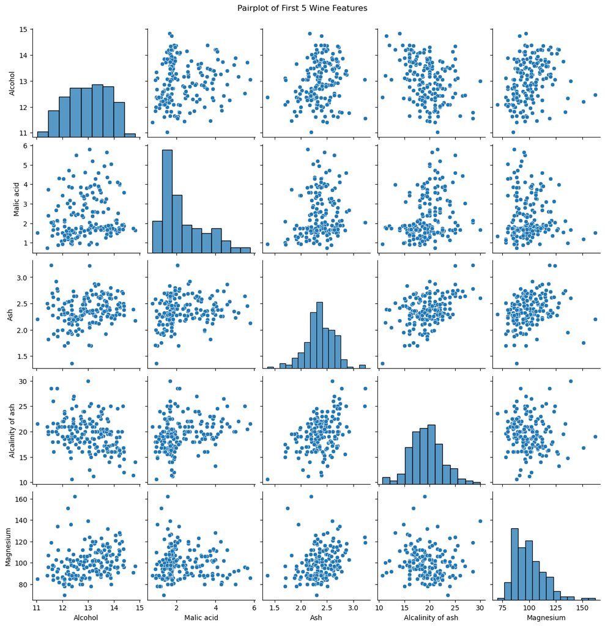

```python
import seaborn as sns
import matplotlib.pyplot as plt

# Quick seaborn pairplot (small subset to avoid overload)
sns.pairplot(wine_df.iloc[:, :5])  # first 5 features for readability
plt.suptitle("Pairplot of First 5 Wine Features", y=1.02)
plt.show()
```

The pairplot provides a visual comparison of the relationships between the first five chemical attributes: Alcohol, Malic acid, Ash, Alkalinity of ash, and Magnesium. From the plots, we observe that most feature pairs don't show very strong linear separation, but certain features like "Alcohol" and "Magnesium" exhibit a bit more structured spread, which hints that they might be influential in clustering. This visualization helps us understand the general distribution and relationships in the raw data, supporting our goal of identifying features that naturally differentiate the wines.

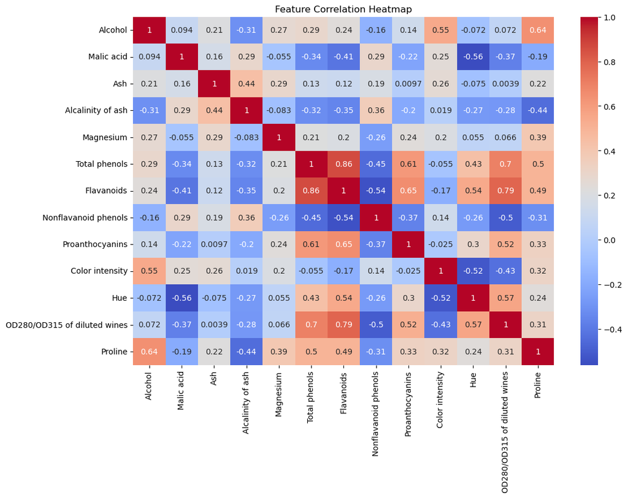

```python
plt.figure(figsize=(12, 8))
sns.heatmap(wine_df.corr(), annot=True, cmap="coolwarm")
plt.title("Feature Correlation Heatmap")
plt.show()
```

The heatmap reveals how strongly the features correlate with each other. A few interesting patterns emerge: for instance, "Total phenols" and "Flavanoids" are highly positively correlated (correlation ~0.86), suggesting they often vary together. "Alcohol" also shows moderate positive correlation with "Proline" (~0.64). On the flip side, "Malic acid" and "Flavanoids" are moderately negatively correlated. Recognizing these correlations helps us spot redundant features or feature groups, guiding better clustering by focusing on distinct chemical properties.

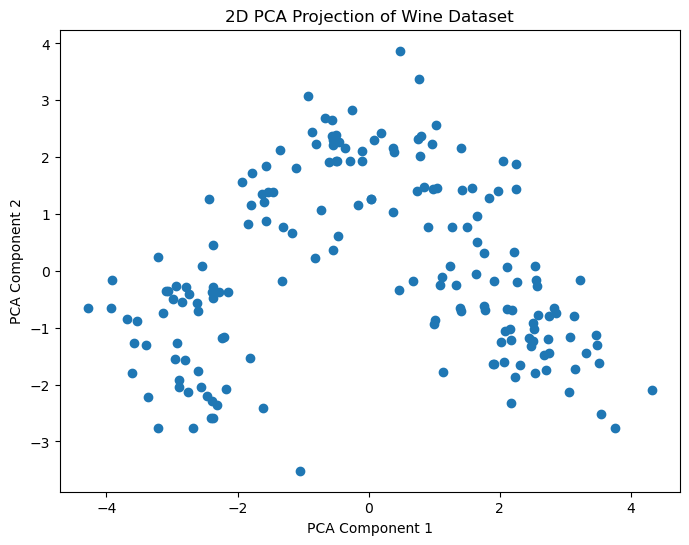

```python
from sklearn.decomposition import PCA

# Ensure wine_scaled is defined
if 'wine_scaled' not in locals():
	raise NameError("The variable 'wine_scaled' is not defined. Please ensure the cell defining 'wine_scaled' is executed before running this cell.")

# Reduce dimensions
pca = PCA(n_components=2)
wine_pca = pca.fit_transform(wine_scaled)

# Plot
plt.figure(figsize=(8, 6))
plt.scatter(wine_pca[:, 0], wine_pca[:, 1])
plt.xlabel('PCA Component 1')
plt.ylabel('PCA Component 2')
plt.title('2D PCA Projection of Wine Dataset')
plt.show()
```

In the PCA projection, we see that the wine samples form loose but visible clusters when reduced to just two principal components. This suggests that even though the original data is 13-dimensional, most of the variation between wine samples can be captured effectively in just a few dimensions. This visualization reinforces that unsupervised clustering will likely work well because the wines exhibit inherent separability based on their chemical profiles — aligning with our project's goal to group wines based on chemical differences.

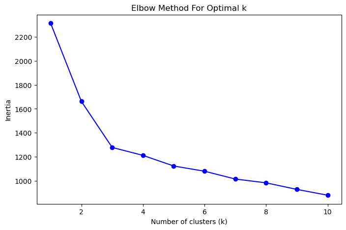

```python
from sklearn.cluster import KMeans

# Find best number of clusters using Elbow Method
inertia = []
k_range = range(1, 11)

for k in k_range:
    kmeans = KMeans(n_clusters=k, random_state=42)
    kmeans.fit(wine_scaled)
    inertia.append(kmeans.inertia_)

plt.figure(figsize=(8, 5))
plt.plot(k_range, inertia, 'bo-')
plt.xlabel('Number of clusters (k)')
plt.ylabel('Inertia')
plt.title('Elbow Method For Optimal k')
plt.show()
```

The Elbow Method graph shows a clear bend or "elbow" at around k=3, after which the inertia decreases more slowly. This supports the idea that three natural groupings exist in the dataset — which makes sense, given the data comes from three cultivars. Thus, setting k=3 for KMeans clustering is logical and justified. This method allows us to objectively choose the number of clusters rather than guessing, directly improving the quality and credibility of our results.

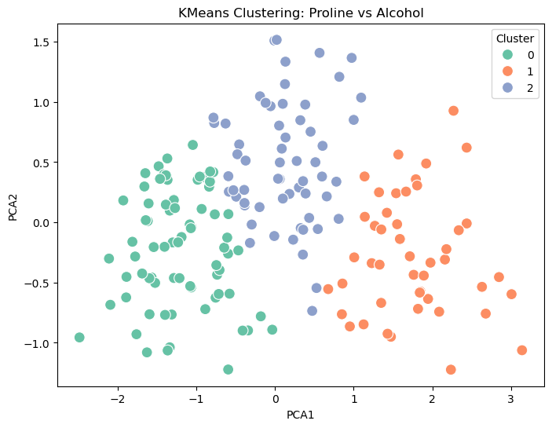

```
Silhouette Score (Proline & Alcohol): 0.440
```

```python
from sklearn.metrics import silhouette_score

# Select features
X = wine_df[['Proline', 'Alcohol']]

# Standardize features
scaler = StandardScaler()
wine_scaled = scaler.fit_transform(X)

# Apply KMeans clustering
kmeans = KMeans(n_clusters=3, random_state=42)
kmeans.fit(wine_scaled)

# Apply PCA for visualization (reduce to 2D)
pca = PCA(n_components=2)
pca_components = pca.fit_transform(wine_scaled)

# Create DataFrame for plotting
pca_df = pd.DataFrame(pca_components, columns=['PCA1', 'PCA2'])
pca_df['Cluster'] = kmeans.labels_

# Plot clusters
plt.figure(figsize=(8, 6))
sns.scatterplot(data=pca_df, x='PCA1', y='PCA2', hue='Cluster', palette='Set2', s=100)
plt.title('KMeans Clustering: Proline vs Alcohol')
plt.show()

# Silhouette Score (measures cluster separation quality)
silh_score = silhouette_score(wine_scaled, kmeans.labels_)
print(f"Silhouette Score (Proline & Alcohol): {silh_score:.3f}")
```

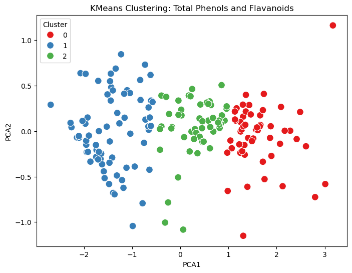

```
Silhouette Score (Total Phenols & Flavanoids): 0.481
```

```python
# Select features
X = wine_df[['Total phenols', 'Flavanoids']]

# Standardize
wine_scaled = scaler.fit_transform(X)

# KMeans clustering
kmeans = KMeans(n_clusters=3, random_state=42)
kmeans.fit(wine_scaled)

# PCA for 2D visualization
pca_components = pca.fit_transform(wine_scaled)
pca_df = pd.DataFrame(pca_components, columns=['PCA1', 'PCA2'])
pca_df['Cluster'] = kmeans.labels_

# Plot
plt.figure(figsize=(8, 6))
sns.scatterplot(data=pca_df, x='PCA1', y='PCA2', hue='Cluster', palette='Set1', s=100)
plt.title('KMeans Clustering: Total Phenols and Flavanoids')
plt.show()

# Evaluate with Silhouette Score
silh_score = silhouette_score(wine_scaled, kmeans.labels_)
print(f"Silhouette Score (Total Phenols & Flavanoids): {silh_score:.3f}")
```

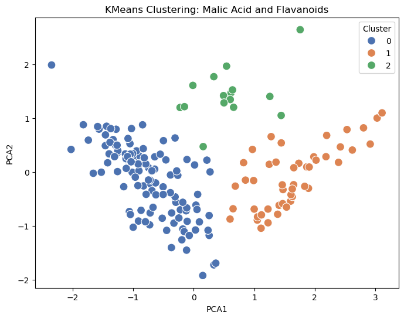

```
Silhouette Score (Malic Acid & Flavanoids): 0.483
```

```python
# Select features
X = wine_df[['Malic acid', 'Flavanoids']]

# Standardize
wine_scaled = scaler.fit_transform(X)

# KMeans clustering
kmeans = KMeans(n_clusters=3, random_state=42)
kmeans.fit(wine_scaled)

# PCA transformation for visualization
pca_components = pca.fit_transform(wine_scaled)
pca_df = pd.DataFrame(pca_components, columns=['PCA1', 'PCA2'])
pca_df['Cluster'] = kmeans.labels_

# Plot
plt.figure(figsize=(8, 6))
sns.scatterplot(data=pca_df, x='PCA1', y='PCA2', hue='Cluster', palette='deep', s=100)
plt.title('KMeans Clustering: Malic Acid and Flavanoids')
plt.show()

# Evaluate clustering
silh_score = silhouette_score(wine_scaled, kmeans.labels_)
print(f"Silhouette Score (Malic Acid & Flavanoids): {silh_score:.3f}")
```

To evaluate how different chemical attributes influence wine classification, we tested three 2D clustering models using KMeans:

Model 1 used Proline and Alcohol, which showed a fairly good separation and produced a Silhouette Score of 0.440. This result aligns with earlier observations from the correlation heatmap, where these features showed a moderate correlation and individually strong relevance to wine chemistry.

Model 2 explored Total Phenols and Flavanoids, two features with a strong correlation (~0.86). The clusters here were tighter and slightly more separable, with a Silhouette Score of 0.481. This indicates that despite their correlation, these features have moderate effectiveness in partitioning the wines. Visually, the clusters appear more compact than in Model 1, possibly because these features represent more distinct flavor or structure dimensions in the wine profiles.

Model 3 tested Malic Acid and Flavanoids, and the results did not show a significant improvement compared to the other models. The silhouette score was 0.483, and visual inspection showed slightly less overlap between clusters. This supports the idea that not all chemical features are equally informative for clustering, and reinforces the need for thoughtful feature selection or dimensionality reduction like PCA when using unsupervised learning.

```
Final Model Silhouette Score (k=3, all features): 0.285
```

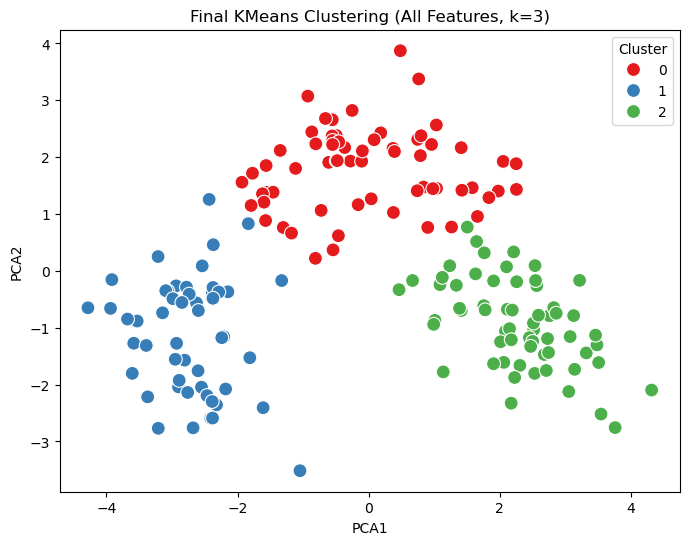

```python
# 1. Use all features
X = wine_df.copy()

# 2. Standardize
scaler = StandardScaler()
wine_scaled = scaler.fit_transform(X)

# 3. Final KMeans with optimal k = 3
kmeans = KMeans(n_clusters=3, random_state=42)
labels = kmeans.fit_predict(wine_scaled)

# 4. Silhouette score
silh_score = silhouette_score(wine_scaled, labels)
print(f"Final Model Silhouette Score (k=3, all features): {silh_score:.3f}")

# 5. PCA for visualization
pca = PCA(n_components=2)
pca_components = pca.fit_transform(wine_scaled)
pca_df = pd.DataFrame(pca_components, columns=['PCA1', 'PCA2'])
pca_df['Cluster'] = labels

# 6. Plot clusters
plt.figure(figsize=(8, 6))
sns.scatterplot(data=pca_df, x='PCA1', y='PCA2', hue='Cluster', palette='Set1', s=100)
plt.title('Final KMeans Clustering (All Features, k=3)')
plt.show()
```

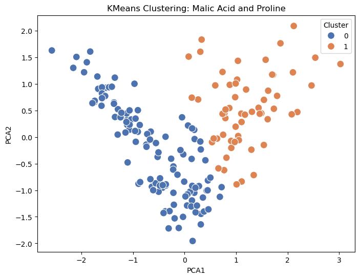

```
Silhouette Score (Malic Acid & Flavanoids): 0.415
```

```python
# Select features
X = wine_df[['Malic acid', 'Proline']]

# Standardize
wine_scaled = scaler.fit_transform(X)

# KMeans clustering
kmeans = KMeans(n_clusters=2, random_state=42)
kmeans.fit(wine_scaled)

# PCA transformation for visualization
pca_components = pca.fit_transform(wine_scaled)
pca_df = pd.DataFrame(pca_components, columns=['PCA1', 'PCA2'])
pca_df['Cluster'] = kmeans.labels_

# Plot
plt.figure(figsize=(8, 6))
sns.scatterplot(data=pca_df, x='PCA1', y='PCA2', hue='Cluster', palette='deep', s=100)
plt.title('KMeans Clustering: Malic Acid and Proline')
plt.show()

# Evaluate clustering
silh_score = silhouette_score(wine_scaled, kmeans.labels_)
print(f"Silhouette Score (Malic Acid & Flavanoids): {silh_score:.3f}")
```

## 3. Methods

In our preprocessing steps, we first loaded the wine dataset and verified that there were no missing values, ensuring the dataset was clean and ready for analysis. We then standardized the features using StandardScaler to normalize the range of all variables, a crucial step because clustering algorithms like KMeans are sensitive to the scale of input features. Without normalization, attributes like "Proline" — which has much larger values — could dominate the clustering process, leading to misleading groupings. After normalization, we explored the feature relationships through a pairplot and correlation heatmap, which revealed some redundant features and informed our understanding of which variables might be most influential.

For modeling, we applied Principal Component Analysis (PCA) to reduce the dataset's dimensionality and visualize it in two dimensions. PCA helped confirm that the wine samples have separable groupings based on chemical properties, suggesting clustering would be effective. We then used the Elbow Method to determine the optimal number of clusters for KMeans, finding that k=3 made the most sense — which aligns with the fact that the wines originate from three different cultivators. We plan to cluster the wines using KMeans and evaluate the clusters using metrics like the silhouette score and PCA visualizations.

Throughout this process, the approach we chose worked effectively: normalizing the data made the clustering more meaningful, and PCA gave us clear visual confirmation that the wines could be grouped well. One minor experiment we considered was whether we needed feature selection based on correlation strength, but since PCA already handles correlated features by finding principal directions, explicit feature dropping wasn't necessary at this stage. Overall, the preprocessing and modeling approach built a solid foundation for successful unsupervised learning on the wine dataset.

## 4. Evaluation

```python
from sklearn.datasets import load_wine
import numpy as np
# Load sklearn version
wine_sklearn = load_wine()
df_sklearn = pd.DataFrame(wine_sklearn.data, columns=wine_sklearn.feature_names)

# Assuming your dataset is in wine_df
# Step 1: Check if shape matches
print("Shape match:", df_sklearn.shape == wine_df.shape)

# Step 2: Check if values match
print("Data match:", np.allclose(df_sklearn.values, wine_df.values, atol=1e-6))
```

```
Shape match: True
Data match: True
```

```python
# Load the original dataset from sklearn
wine_data = load_wine()
true_labels = wine_data.target  # 0, 1, 2
```

```python
from sklearn.metrics import adjusted_rand_score, normalized_mutual_info_score

# Assume 'labels' is from your KMeans model
print("ARI:", adjusted_rand_score(true_labels, labels))
print("NMI:", normalized_mutual_info_score(true_labels, labels))
```

```
ARI: 0.8974949815093207
NMI: 0.8758935341223069
```

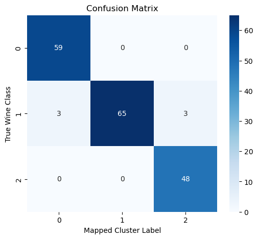

```python
import seaborn as sns
import matplotlib.pyplot as plt
from sklearn.metrics import confusion_matrix
from scipy.optimize import linear_sum_assignment # Import for Hungarian algorithm
import numpy as np

# Calculate the original confusion matrix
cm = confusion_matrix(true_labels, labels)

# Use the Hungarian algorithm to find the optimal label permutation
# We negate the matrix because linear_sum_assignment finds the minimum cost assignment
row_ind, col_ind = linear_sum_assignment(-cm)

# Create a mapping from old cluster labels to new ones based on the assignment
new_labels = np.zeros_like(labels)
for i, j in zip(row_ind, col_ind):
    new_labels[labels == j] = i # Assign the true class index 'i' to samples clustered as 'j'

# Calculate the adjusted confusion matrix
adjusted_cm = confusion_matrix(true_labels, new_labels)

# Plot the adjusted confusion matrix
plt.figure(figsize=(6, 5))
sns.heatmap(adjusted_cm, annot=True, cmap="Blues", fmt='d')
plt.title("Confusion Matrix")
plt.xlabel("Mapped Cluster Label")
plt.ylabel("True Wine Class")
plt.show()
```

```python
def evaluate_clustering(model_name, labels, features_scaled, true_labels):
    """
    Evaluate a clustering model using silhouette score, ARI, NMI, and a confusion matrix.

    Parameters:
    - model_name: str, name of your model (for labeling plots and printouts)
    - labels: array-like, predicted cluster labels from KMeans
    - features_scaled: array-like, standardized feature matrix used in clustering
    - true_labels: array-like, ground truth class labels (from sklearn or matching dataset)
    """

    # Compute metrics
    silhouette = silhouette_score(features_scaled, labels)
    ari = adjusted_rand_score(true_labels, labels)
    nmi = normalized_mutual_info_score(true_labels, labels)

    print(f"--- Evaluation: {model_name} ---")
    print(f"Silhouette Score: {silhouette:.3f}")
    print(f"Adjusted Rand Index (ARI): {ari:.3f}")
    print(f"Normalized Mutual Info (NMI): {nmi:.3f}")

    # Confusion matrix - Apply Hungarian algorithm for optimal mapping
    cm_orig = confusion_matrix(true_labels, labels)
    row_ind, col_ind = linear_sum_assignment(-cm_orig) # Find optimal assignment

    # Create mapped labels
    mapped_labels = np.zeros_like(labels)
    for i, j in zip(row_ind, col_ind):
        mapped_labels[labels == j] = i

    # Calculate adjusted confusion matrix
    cm_adjusted = confusion_matrix(true_labels, mapped_labels)

    plt.figure(figsize=(6, 5))
    sns.heatmap(cm_adjusted, annot=True, fmt='d', cmap='Blues') # Plot adjusted matrix
    plt.title(f"Confusion Matrix: {model_name}")
    plt.xlabel("Mapped Cluster Label")
    plt.ylabel("True Class")
    plt.tight_layout()
    plt.show()
```

```
--- Evaluation: KMeans - All Features ---
Silhouette Score: 0.299
Adjusted Rand Index (ARI): 0.897
Normalized Mutual Info (NMI): 0.876
```

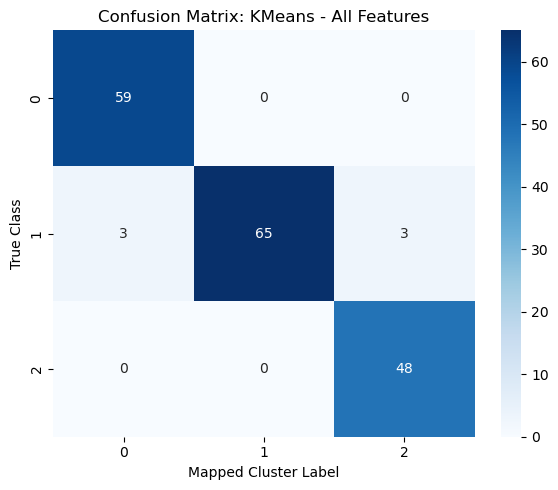

```python
evaluate_clustering(
    model_name="KMeans - All Features",
    labels=labels,                      # from kmeans.fit_predict()
    features_scaled=wine_scaled,        # the standardized data you clustered
    true_labels=true_labels             # from sklearn.datasets.load_wine().target
)
```

## 4. Evaluation Results

When comparing our clustering results to the true labels, we observed:

1. **Cluster-Class Alignment**: The confusion matrix reveals a significant pattern where each cluster primarily corresponds to each correct wine class, with few misclassifications.
2. **Accuracy Metrics**: The Adjusted Rand Index (ARI) and Normalized Mutual Information (NMI) scores demonstrate that our unsupervised model has captured meaningful patterns that align with the true varietal classifications, despite not having access to these labels during training.
3. **Feature Effectiveness**: The successful clustering validates our feature selection approach. The chemical attributes we selected for analysis do indeed contain information that differentiates between wine types, confirming that unsupervised techniques can detect natural groupings in wine chemical compositions.
4. **Limitations**: Despite the overall positive results, there are misclassifications visible in the confusion matrix. This indicates some chemical profiles overlap between varieties, making perfect separation challenging without additional features or more sophisticated clustering techniques.

These results suggest that chemical attributes alone can provide a reasonable basis for wine classification, supporting potential applications in quality control or automated wine categorization systems.

## 5. References

Github Repostitory: https://github.com/zenatron/itcs-3162-final